# map

Aaron Gong

04/28/2022

```r
# Load packages

library(tidyverse)
library(ggmap)
library(forcats)
```

## Research Question: What is the spatial distribution of car accidents and their severity?

## Modify data

We want to represent each accident as a point on the map, so we modify our data to obtain the so-called **point pattern data**. The original data only provides a range of longitude and latitude of each accident (given by `Start_Lat`, `End_Lat`, `Start_Lng`, and `End_Lng`). In our modification, we compute `Center_Lat` and `Center_Lng`, giving us the center coordinate of the accident, which we will use to plot on the US map.

```r
accidents = read.csv("./data/accidents_modified.csv")

# Delete unused columns
# accidents = subset(accidents, select = -c(End_Time, Description, Country,
#                                           Civil_Twilight, Nautical_Twilight,
#                                           Astronomical_Twilight))
# Convert Severity to factor
accidents$Severity = factor(accidents$Severity)

# write.csv(accidents, "./data/accidents_modified.csv", row.names = FALSE)

# Compute center latitude and longitude
accidents$Center_Lat = (accidents$Start_Lat + accidents$End_Lat) / 2
accidents$Center_Lng = (accidents$Start_Lng + accidents$End_Lng) / 2

# head(accidents)
```

## 1. Accidents in Top 20 Metropolitans

What are the cities in the US with most car accidents? We first draw the top 20 metropolitans with the most number of car accidents. We create a stacked bar plot, displaying the conditional distribution of `Severity` of accidents for each metropolitan.

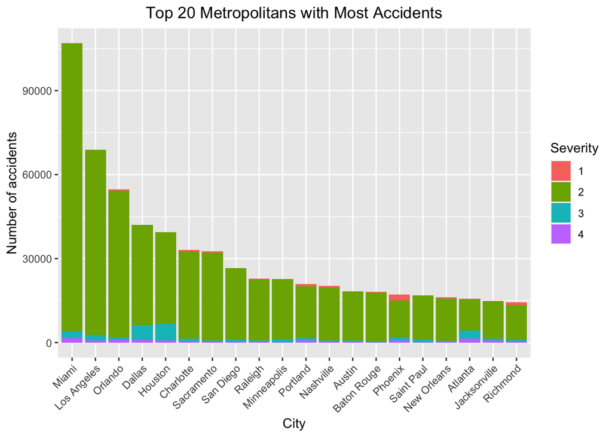

```r
# 1. Major cities stakced bar plot


metros = data.frame(sort(table(accidents$City), decreasing=TRUE)[1:20])
metro_accidents = accidents %>% filter(City %in% metros$Var1)
# head(metro_accidents)

ggplot(data = metro_accidents, aes(fct_infreq(City), fill = Severity)) +
  geom_bar() +
  scale_x_discrete(guide = guide_axis(angle = 45)) +
  labs(
    x = "City",
    y = "Number of accidents",
    title = "Top 20 Metropolitans with Most Accidents"
  ) +
  theme(plot.title = element_text(hjust = 0.5))
```

The graph above shows the top 20 metropolitans with most accidents. In particular, the top 3 cities are Miami, Los Angeles, and Orlando, two of which are in Florida. The number of accidents in Miami is way higher compared to any other city. In terms of severity, most of the accidents have a severity level of 2. Other levels of severity seem to take up a negligible proportion for the majority of the cities, except for Dallas, Houston, and Atlanta. Level 3 (more severe) accidents take up a relatively significant proportion for Dallas and Houston, both of which are in Texas. For Atlanta, GA, Level 3 and Level 4 accidents both take up a noticeable proportion.

## 2. Accidents density plot

We then create a graph that shows the density of car accidents across the US.

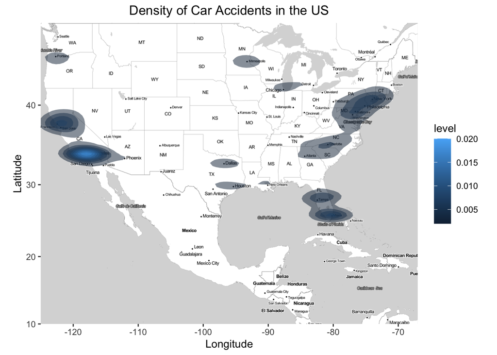

```r
# 2. Accidents density plot

# Load US Map
US <- c(left = -125, bottom = 10, right = -67, top = 49)
map <- get_stamenmap(US, zoom = 5, maptype = "toner-lite")


set.seed(315)
samp = sample(1:nrow(accidents), size=100000, replace=FALSE)
ggmap(map) +
  stat_density2d(data = accidents[samp,],
                 aes(x = Center_Lng, y = Center_Lat, fill = after_stat(level)),
                 alpha = 0.5, geom = "polygon") +
  labs(
    x = "Longitude",
    y = "Latitude",
    title = "Density of Car Accidents in the US"
  ) +
  theme(plot.title = element_text(hjust = 0.5))
```

As shown in the graph, most car accidents happen in the metropolitan areas that we identified above. In particular, accidents are clustered in: Los Angeles (Southern California), the Bay Area (Northern California), Miami and Orlando (Florida), New York, Philadelphia, Charlotte (Northeastern part), as well as some other cities including Dallas, Houston, Portland, Chicago, Minneapolis, etc. The number of car accidents in other small cities and (rural) areas is insignificant compared to these metropolitan areas.

## 3. Distribution of Severity

How severe are the accidents in different parts of the US? In other words, how is the `Severity` variable of accidents distributed across the US? We make a plot of all accidents on the map, colored by their severity.

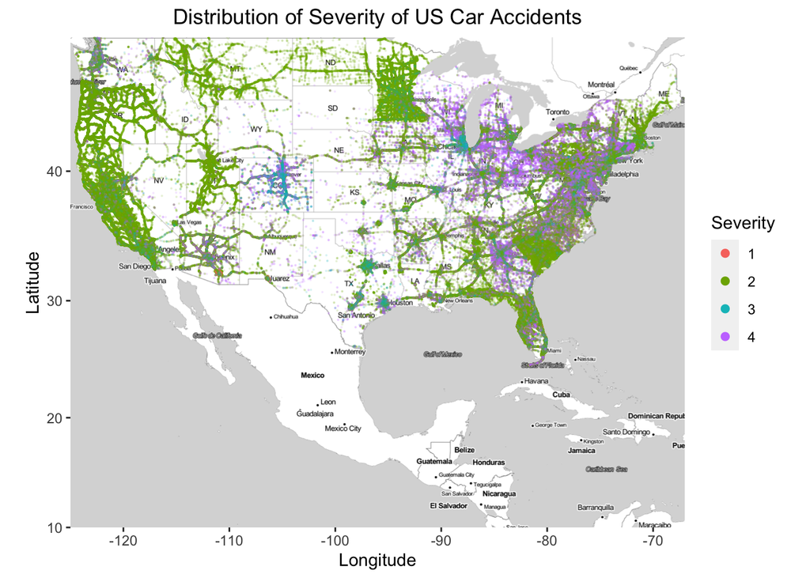

```r
# 3. Distribution of Severity

ggmap(map) +
  geom_point(data = accidents,
             aes(x = Center_Lng, y = Center_Lat, color = Severity), size = 0.1,
             alpha = .1) +
  guides(color = guide_legend(override.aes = list(alpha = 1, size = 2))) +
  labs(
    x = "Longitude",
    y = "Latitude",
    title = "Distribution of Severity of US Car Accidents"
  ) +
  theme(plot.title = element_text(hjust = 0.5))
```